# Reproducible Research Project 1

Jeffrey M. Hunter

4/18/2019

## Table of Contents

Introduction  
Set Up Environment  
Questions  
Loading and preprocessing the data  
What is mean total number of steps taken per day?  
What is the average daily activity pattern?  
Imputing missing values  
Are there differences in activity patterns between weekdays and weekends?

## Introduction

It is now possible to collect a large amount of data about personal movement using activity monitoring devices such as a [Fitbit](http://www.fitbit.com/), [Nike Fuelband](http://www.nike.com/us/en_us/c/nikeplus-fuelband), or [Jawbone Up](https://jawbone.com/up). These type of devices are part of the “quantified self” movement - a group of enthusiasts who take measurements about themselves regularly to improve their health, to find patterns in their behavior, or because they are tech geeks. But these data remain under-utilized both because the raw data are hard to obtain and there is a lack of statistical methods and software for processing and interpreting the data.

This assignment makes use of data from a personal activity monitoring device. This device collects data at 5 minute intervals through out the day. The data consists of two months of data from an anonymous individual collected during the months of October and November, 2012 and include the number of steps taken in 5 minute intervals each day.

The data for this assignment can be downloaded from the course web site.

The variables included in this dataset are:

- **steps**: Number of steps taking in a 5-minute interval (missing values are coded as `NA`)
- **date**: The date on which the measurement was taken in YYYY-MM-DD format
- **interval**: Identifier for the 5-minute interval in which measurement was taken

The dataset is stored in a comma-separated-value (CSV) file and there are a total of 17,568 observations in this dataset.

## Set Up Environment

```r
knitr::opts_chunk$set(echo = FALSE)
```

Load libraries

```r
library(dplyr, warn.conflicts = FALSE)
library(ggplot2)
```

## Questions

Reports will be run to answer specified in the homework assignment.

### Loading and preprocessing the data

Load and process the dataset

```r
setwd("~jhunter/repos/coursera/reproducible-research-course-project-1")
activityDataFile <- "data/activity.csv"
if (!file.exists(activityDataFile)) {
    tempFile <- tempfile()
    download.file("https://d396qusza40orc.cloudfront.net/repdata%2Fdata%2Factivity.zip", tempFile)
    unzip(tempFile, exdir = "data")
    unlink(tempFile)
}
activityData <- read.csv(activityDataFile, sep = ",")
activityData$date <- as.POSIXct(activityData$date, format = "%Y-%m-%d", tz = "")
```

Display dataset summary

```r
names(activityData)
```

```
## [1] "steps"    "date"     "interval"
```

```r
str(activityData)
```

```
## 'data.frame':    17568 obs. of  3 variables:
##  $ steps   : int  NA NA NA NA NA NA NA NA NA NA ...
##  $ date    : POSIXct, format: "2012-10-01" "2012-10-01" ...
##  $ interval: int  0 5 10 15 20 25 30 35 40 45 ...
```

```r
summary(activityData)
```

```
##      steps             date                        interval
##  Min.   :  0.00   Min.   :2012-10-01 00:00:00   Min.   :   0.0
##  1st Qu.:  0.00   1st Qu.:2012-10-16 00:00:00   1st Qu.: 588.8
##  Median :  0.00   Median :2012-10-31 00:00:00   Median :1177.5
##  Mean   : 37.38   Mean   :2012-10-31 00:25:34   Mean   :1177.5
##  3rd Qu.: 12.00   3rd Qu.:2012-11-15 00:00:00   3rd Qu.:1766.2
##  Max.   :806.00   Max.   :2012-11-30 00:00:00   Max.   :2355.0
##  NA's   :2304
```

```r
head(activityData)
```

|  | steps | date | interval |
| --- | --- | --- | --- |
| 1 | NA | 2012-10-01 | 0 |
| 2 | NA | 2012-10-01 | 5 |
| 3 | NA | 2012-10-01 | 10 |
| 4 | NA | 2012-10-01 | 15 |
| 5 | NA | 2012-10-01 | 20 |
| 6 | NA | 2012-10-01 | 25 |

### What is mean total number of steps taken per day?

Calculate steps per day (excluding missing values)

```r
stepsPerDay <- with(activityData, aggregate(steps, list(date), FUN = sum, na.rm = TRUE))
colnames(stepsPerDay) <- c("Date", "Steps")
head(stepsPerDay)
```

|  | Date | Steps |
| --- | --- | --- |
| 1 | 2012-10-01 | 0 |
| 2 | 2012-10-02 | 126 |
| 3 | 2012-10-03 | 11352 |
| 4 | 2012-10-04 | 12116 |
| 5 | 2012-10-05 | 13294 |
| 6 | 2012-10-06 | 15420 |

Display histogram

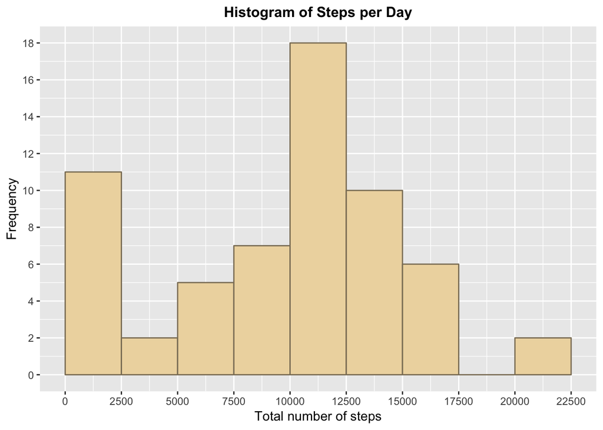

```r
gp1 <- ggplot(stepsPerDay, aes(stepsPerDay$Steps))
gp1 + geom_histogram(boundary = 0, binwidth = 2500, col = "wheat4", fill = "wheat2") + ggtitle("Histogram of Steps per Day") + xlab("Total number of steps") + ylab("Frequency") + theme(plot.title = element_text(face = "bold", size = 12, hjust = 0.5)) + scale_x_continuous(breaks = seq(0, 25000, 2500)) + scale_y_continuous(breaks = seq(0, 18, 2))
```

Mean and median number of steps taken each day

Mean (excluding missing values)

```r
mean(stepsPerDay$Steps, na.rm = TRUE)
```

```
## [1] 9354.23
```

Median (excluding missing values)

```r
median(stepsPerDay$Steps, na.rm = TRUE)
```

```
## [1] 10395
```

**Note**: adding `na.rm = TRUE` was not necessary since the `stepsPerDay` data frame already excluded `NA` values.

### What is the average daily activity pattern?

Calculate steps per time interval

```r
stepsPerIntervalAvg <- aggregate(steps ~ interval, data = activityData, FUN = mean, na.action = na.omit)
colnames(stepsPerIntervalAvg) <- c("interval", "steps")
```

Make a time series plot (i.e. type = “l”) of the 5-minute interval (x-axis) and the average number of steps taken, averaged across all days (y-axis)

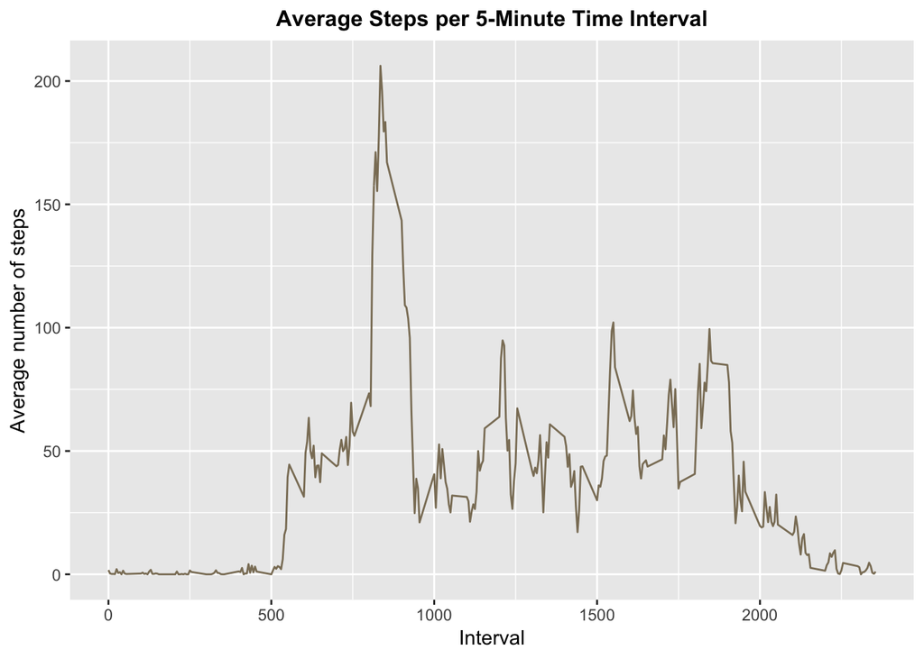

```r
gp2 <- ggplot(stepsPerIntervalAvg, aes(stepsPerIntervalAvg$interval, stepsPerIntervalAvg$steps))
gp2 + geom_line(col = "wheat4") + ggtitle("Average Steps per 5-Minute Time Interval") + xlab("Interval") + ylab("Average number of steps") + theme(plot.title = element_text(face = "bold", size = 12, hjust = 0.5))
```

Which 5-minute interval, on average across all the days in the dataset, contains the maximum number of steps?

```r
activityData %>% group_by(interval) %>%
    summarize(meanByInterval = mean(steps, na.rm = TRUE)) %>%
    filter(meanByInterval == max(meanByInterval))
```

| interval | meanByInterval |
| --- | --- |
| 835 | 206.1698 |

### Imputing missing values

There are a number of days/intervals where there are missing values (coded as `NA`). The presence of missing days may introduce bias into some calculations or summaries of the data.

Calculate and report the total number of missing values in the dataset (i.e. the total number of rows with `NA`s)

```r
sum(is.na(activityData$steps) == TRUE)
```

```
## [1] 2304
```

Devise a strategy for filling in all of the missing values in the dataset. The strategy does not need to be sophisticated. For example, you could use the mean/median for that day, or the mean for that 5-minute interval, etc.

Strategy: Add a new column to the origin dataset named `steps_completed` that replaces missing values with the rounded average of the 5-minute interval.

```r
activityData$steps_completed <- ifelse(is.na(activityData$steps), round(stepsPerIntervalAvg$steps[match(activityData$interval, stepsPerIntervalAvg$interval)], 0), activityData$steps)
```

Create a new dataset that is equal to the original dataset but with the missing data filled in.

```r
activityDataNoNA <- data.frame(steps = activityData$steps_completed, interval = activityData$interval, date = activityData$date)
head(activityDataNoNA, n = 10)
```

|  | steps | interval | date |
| --- | --- | --- | --- |
| 1 | 2 | 0 | 2012-10-01 |
| 2 | 0 | 5 | 2012-10-01 |
| 3 | 0 | 10 | 2012-10-01 |
| 4 | 0 | 15 | 2012-10-01 |
| 5 | 0 | 20 | 2012-10-01 |
| 6 | 2 | 25 | 2012-10-01 |
| 7 | 1 | 30 | 2012-10-01 |
| 8 | 1 | 35 | 2012-10-01 |
| 9 | 0 | 40 | 2012-10-01 |
| 10 | 1 | 45 | 2012-10-01 |

Make a histogram of the total number of steps taken each day and calculate and report the **mean** and **median** total number of steps taken per day. Do these values differ from the estimates from the first part of the assignment? What is the impact of imputing missing data on the estimates of the total daily number of steps?

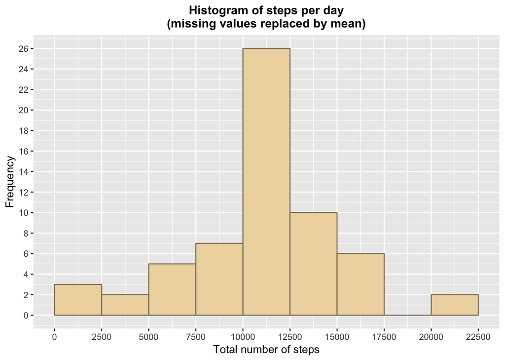

```r
stepsPerDayCompleted <- aggregate(activityDataNoNA$steps, list(activityDataNoNA$date), FUN = sum)
colnames(stepsPerDayCompleted) <- c("date", "steps")
gp3 <- ggplot(stepsPerDayCompleted, aes(stepsPerDayCompleted$steps))
gp3 + geom_histogram(boundary = 0, binwidth = 2500, col = "wheat4", fill = "wheat2") + ggtitle("Histogram of steps per day\n(missing values replaced by mean)") + xlab("Total number of steps") + ylab("Frequency") + theme(plot.title = element_text(face = "bold", size = 12, hjust = 0.5)) + scale_x_continuous(breaks = seq(0, 25000, 2500)) + scale_y_continuous(breaks=seq(0, 26, 2))
```

Calculate and report the mean and median total number of steps taken per day.

Mean

```r
mean(stepsPerDayCompleted$steps)
```

```
## [1] 10765.64
```

Median

```r
median(stepsPerDayCompleted$steps)
```

```
## [1] 10762
```

Do these values differ from the estimates from the first part of the assignment?

What is the impact of imputing missing data on the estimates of the total daily number of steps?

| Statistic | Original Dataset | Imputed Dataset | Difference |
| --- | --- | --- | --- |
| mean | 9,354.23 | 10,765.64 | 1,411.41 (15%) |
| median | 10,395 | 10,762 | 367 (3%) |

### Are there differences in activity patterns between weekdays and weekends?

For this part, the `weekdays()` function may be of some help here. Use the dataset with the filled-in missing values for this part.

```r
weekDay <- weekdays(activityDataNoNA$date, abbreviate = FALSE)
activityDataNoNA <- cbind(activityDataNoNA, weekDay)
names(activityDataNoNA)[4] <- "week_day"
head(activityDataNoNA, n = 10)
```

|  | steps | interval | date | week_day |
| --- | --- | --- | --- | --- |
| 1 | 2 | 0 | 2012-10-01 | Monday |
| 2 | 0 | 5 | 2012-10-01 | Monday |
| 3 | 0 | 10 | 2012-10-01 | Monday |
| 4 | 0 | 15 | 2012-10-01 | Monday |
| 5 | 0 | 20 | 2012-10-01 | Monday |
| 6 | 2 | 25 | 2012-10-01 | Monday |
| 7 | 1 | 30 | 2012-10-01 | Monday |
| 8 | 1 | 35 | 2012-10-01 | Monday |
| 9 | 0 | 40 | 2012-10-01 | Monday |
| 10 | 1 | 45 | 2012-10-01 | Monday |

Create a new factor variable in the dataset with two levels – “weekday” and “weekend” indicating whether a given date is a weekday or weekend day.